# Assignment 8: Bootstrap Methods and Applications

Josie Gallop

Due: 03-31-2026

## **Assignment Objectives**

- Reinforce the understanding of Bootstrap sampling .
- Understand the bootstrap estimation: confidence interval and sampling distribution.

## **Policies of Using AI Tools**

**Policy on AI Tool Use**: Please adhere to the AI tool policy specified in the course syllabus. The direct copying of AI-generated content is strictly prohibited. All submitted work must reflect your own understanding; where external tools are consulted, content must be thoroughly rephrased and synthesized in your own words.

**Code Inclusion Requirement**: Any code included in your essay must be properly commented to explain the purpose and/or expected output of key code lines. Submitting AI-generated code without meaningful, student-added comments will not be accepted.

**Log-normal Distribution Revisited**

If $Y = \ln(X) \sim N(\mu, \sigma^2)$, then $X$ follows a lognormal distribution $X \sim \text{Lognormal}(\mu, \sigma^2)$. The probability density is given by

$$f(x|\mu,\sigma) = \frac{1}{x\sigma\sqrt{2\pi}} \exp\left(-\frac{(\ln x -
\mu)^2}{2\sigma^2}\right), \quad x > 0$$

After some algebra, we can express the mean and variance of the above lognormal distribution in the following

$$\begin{align}
\mathbb{E}[X] &= \exp\left(\mu + \frac{\sigma^2}{2}\right) \\
\text{Var}(X) &= [\exp(\sigma^2) - 1] \exp(2\mu + \sigma^2)
\end{align}$$

Using the relationship between normal and log-normal distribution and a sample $\{x_1, x_2, \dots, x_n\}$, the MLE estimators of $\mu$ and $\sigma^2$ are given by

$$\begin{align}
\hat{\mu} &= \frac{1}{n}\sum_{i=1}^n \ln(x_i) \\
\hat{\sigma}^2 &= \frac{1}{n}\sum_{i=1}^n (\ln(x_i) - \hat{\mu})^2
\end{align}$$

Using the plug-in principle of MLE, we have the MLE of $\mathbb{E}[X]$ and $\text{Var}(X)$ in the following

$$\boxed{\widehat{\mathbb{E}[X]} = \exp\left(\hat{\mu} +
\frac{\hat{\sigma}^2}{2}\right)}$$

**This assignment focuses on constructing various bootstrap confidence intervals of the lognormal population mean $\mathbb{E}[X]$**

## **Question: Trace Metal Concentrations in Soil**

Soil lead (Pb) concentrations (mg/kg) from 55 urban garden sites. Trace metals in environmental media typically follow lognormal distributions due to:

- Multiplicative processes controlling accumulation
- Positive constraints (concentrations cannot be negative)
- Right-skewed nature of contamination patterns

```
0.85, 1.23, 0.92, 3.45, 2.11, 1.56, 4.89, 2.34, 1.78, 6.72, 0.95, 1.34, 8.91,
2.67, 1.89, 5.43, 1.12, 3.78, 2.45, 7.65, 1.05, 1.45, 12.34, 2.89, 2.01, 4.56,
1.23, 4.32, 2.67, 9.87, 0.99, 1.56, 15.23, 3.12, 2.34, 3.89, 1.34, 5.67, 2.89,
11.45, 1.12, 1.67, 18.90, 3.45, 2.56, 3.45, 1.45, 6.78, 3.12, 14.56, 1.23, 1.78,
22.34, 3.78, 2.78
```

Assume the data follow a log‑normal distribution. For each question, first describe your reasoning for the analysis, then write code to carry out the analysis. Finally, summarize the results to draw a conclusion.

a). Perform 5000 bootstrap samples to estimate the bootstrap sampling distribution of $\boxed{\widehat{\mathbb{E}[X]}}$. Display the distribution using either a histogram or a kernel density plot. Comment on the shape, variability, and any notable patterns observed in the bootstrap sampling distribution.

I will begin by storing the observations within in a data set called ‘lead’. These observations represent amounts of soil lead concentrations from 55 urban garden sites.

```r
lead <- c(0.85, 1.23, 0.92, 3.45, 2.11, 1.56, 4.89, 2.34, 1.78, 6.72, 0.95, 1.34, 8.91, 2.67, 1.89, 5.43, 1.12, 3.78, 2.45, 7.65, 1.05, 1.45, 12.34, 2.89, 2.01, 4.56, 1.23, 4.32, 2.67, 9.87, 0.99, 1.56, 15.23, 3.12, 2.34, 3.89, 1.34, 5.67, 2.89, 11.45, 1.12, 1.67, 18.90, 3.45, 2.56, 3.45, 1.45, 6.78, 3.12, 14.56, 1.23, 1.78, 22.34, 3.78, 2.78)
```

Before beginning the bootstrap sampling process, I will create a simple histogram to visualize the distribution of the lead data.

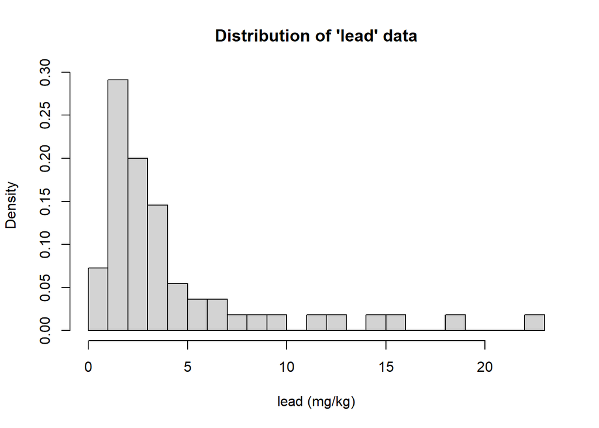

```r
# Histogram of the lead data
hist(lead, breaks = 20, probability = TRUE,
     main = "Distribution of 'lead' data",
     xlab = "lead (mg/kg)")
```

It appears that the lead data is very skewed to the right. The data is not symmetric and is not normally distributed, as it is quite severely skewed. I will keep this in mind when making future considerations with the different confidence intervals I will make in the coming parts.

I will perform 5,000 Bootstrap samples to estimate the bootstrap sampling distribution of the lognormal population mean, $\widehat{\mathbb{E}[X]}$. I will plot the bootstrap sampling distribution as a histogram in order to visualize how the estimate of the lognormal population mean, $\mathbb{E}[X]$, is distributed.

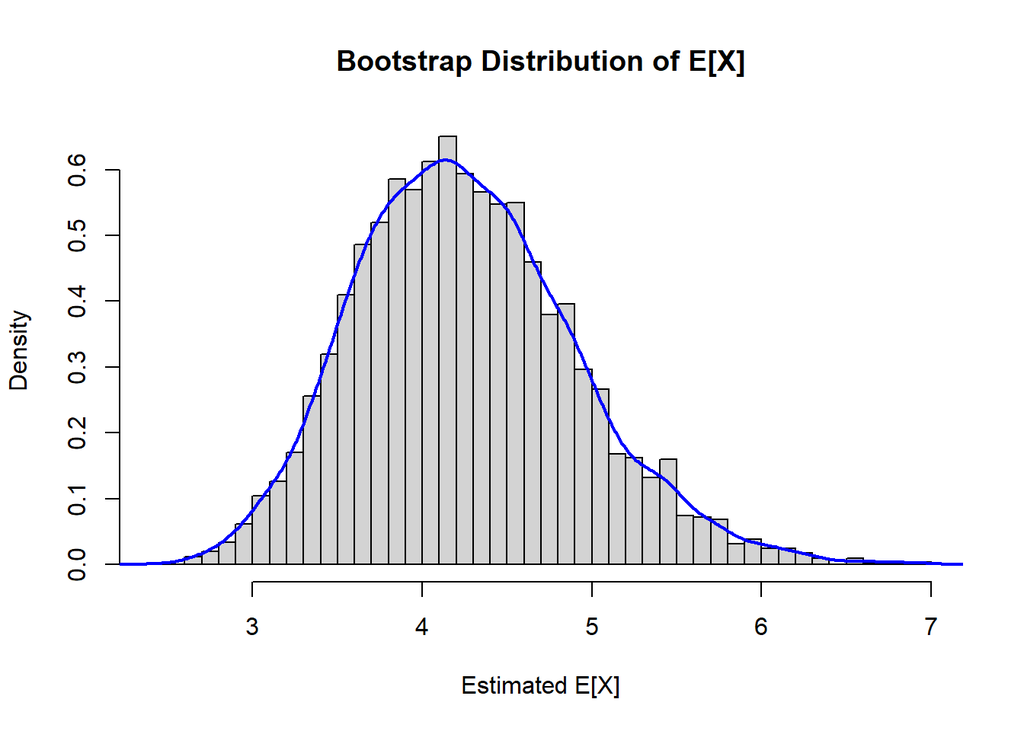

```r
n <- length(lead)

set.seed(123)

# 5,000 Bootstrap samples
B <- 5000
boot_mean <- numeric(B)

for (b in 1:B) {
  xb <- sample(lead, size = n, replace = TRUE)

  log_xb <- log(xb)
  mu_hat <- mean(log_xb)
  sigma2_hat <- var(log_xb)

  boot_mean[b] <- exp(mu_hat + sigma2_hat / 2)
}

# Histogram of the Bootstrap sampling distribution
hist(boot_mean, breaks = 40, probability = TRUE,
     main = "Bootstrap Distribution of E[X]",
     xlab = "Estimated E[X]")
lines(density(boot_mean), col = "blue", lwd = 2)
```

The Bootstrap distribution appears to be unimodal with a somewhat noticeable skew to the right. This is reasonable as the lead data itself was so severely skewed to the right, so even with 5,000 bootstrap samples, some of this skewness to the right still lingers even though it is not nearly as severe in this bootstrap sampling distribution compared to the distribution of the lead data. The mean of the sampling distribution appears to be right around 4, meaning that the estimated value of the lognormal population mean for this data should be close to 4 as well.

b). Construct a 95% bootstrap percentile confidence interval for $\mu_{LN} = \mathbb{E}[X]$.

Next, I will construct a 95% bootstrap percentile confidence interval for $\mu_{LN} = \mathbb{E}[X]$. To get this 95% bootstrap percentile confidence interval, I will find the 2.5% and 97.5% percentiles of the bootstrap estimates. This will get a 95% confidence interval for $\mu_{LN} = \mathbb{E}[X]$.

```r
# 95% bootstrap percentile confidence interval
ci_percentile <- quantile(boot_mean, c(0.025, 0.975))
ci_percentile
```

```
    2.5%    97.5%
3.110817 5.683647
```

The 95% bootstrap percentile confidence interval for $\mu_{LN} = \mathbb{E}[X]$ is [3.1108, 5.6836]; B=5,000, n=55.

c). Construct a 95% bootstrap BCa confidence interval for $\mu_{LN} = \mathbb{E}[X]$.

Next, I will construct a 95% bootstrap BCa confidence interval for $\mu_{LN} = \mathbb{E}[X]$. This BCa, or bias-corrected and accelerated, confidence interval will serve as an improved confidence interval because it adjusts for both bias and skewness in the sampling distribution. This is good for this specific model as it was seen that the bootstrap sampling distribution indeed was skewed to the right. I will begin by manually finding this 95% bootstrap BCa confidence interval. Then, I will use the boot library to create my R function for this 95% bootstrap BCa confidence interval for $\mu_{LN} = \mathbb{E}[X]$ and verify the results.

```r
# Manually finding the 95% bootstrap BCa confidence interval
log_x <- log(lead)
mu_hat <- mean(log_x)
sigma2_hat <- var(log_x)
EX_hat <- exp(mu_hat + sigma2_hat / 2)

# Bias correction
z0 <- qnorm(mean(boot_mean < EX_hat))

# Jackknife estimates
jack_est <- numeric(n)

for (i in 1:n) {
  x_jack <- lead[-i]
  logx_jack <- log(x_jack)
  mu_j <- mean(logx_jack)
  sigma2_j <- var(logx_jack)
  jack_est[i] <- exp(mu_j + sigma2_j / 2)
}

jack_mean <- mean(jack_est)

num <- sum((jack_mean - jack_est)^3)
den <- 6 * (sum((jack_mean - jack_est)^2))^(3/2)
a <- num / den

# Quartiles for a 95% Confidence Interval
alpha <- c(0.025, 0.975)
z_alpha <- qnorm(alpha)
adj_alpha <- pnorm(z0 + (z0 + z_alpha) / (1 - a * (z0 + z_alpha)))

# Find the BCa Confidence Interval
ci_bca_manual <- quantile(boot_mean, adj_alpha)
ci_bca_manual
```

```
4.196505%  98.7084%
 3.244080  5.915138
```

The 95% bootstrap BCa confidence interval for $\mu_{LN} = \mathbb{E}[X]$ is [3.244, 5.915]; B=5,000, n=55.

Next, I will verify these findings by using the boot library to calculate a 95% bootstrap BCa confidence interval. I expect these results to match up with the 95% bootstrap BCa confidence interval that I manually found with R code functions.

```r
# Using the boot library to verify the BCa confidence interval
library(boot)

boot_fun <- function(data, indices) {
  xb <- data[indices]
  mu_hat <- mean(log(xb))
  sigma2_hat <- var(log(xb))
  return(exp(mu_hat + sigma2_hat / 2))
}
boot_obj <- boot(lead, statistic = boot_fun, R = 5000)

# 95% bootstrap BCa confidence interval
ci_bca <- boot.ci(boot_obj, type = "bca")
ci_bca
```

```
BOOTSTRAP CONFIDENCE INTERVAL CALCULATIONS
Based on 5000 bootstrap replicates

CALL :
boot.ci(boot.out = boot_obj, type = "bca")

Intervals :
Level       BCa
95%   ( 3.241,  5.848 )
Calculations and Intervals on Original Scale
```

The 95% bootstrap BCa confidence interval for $\mu_{LN} = \mathbb{E}[X]$ is [3.241, 5.848]; B=5,000, n=55.

d). Use the Central Limit Theorem to construct a 95% asymptotic confidence interval for $\mu_{LN} = \mathbb{E}[X]$.

I will now use the Central Limit Theorem to construct a 95% asymptotic confidence interval for $\mu_{LN} = \mathbb{E}[X]$. In order to create this confidence interval, I will estimate the standard error from the bootstrap sampling distribution’s standard deviation. I know that $\hat{\theta} \pm z_{0.975} \cdot \mathrm{SE}$ can be used to calculate the confidence interval bounds, so I will use this to create my 95% asymptotic confidence interval.

```r
EX_hat <- mean(boot_mean)
SE_hat <- sd(boot_mean)

# 95% asymptotic confidence interval
z <- qnorm(0.975)

ci_clt <- c(EX_hat - z * SE_hat,
            EX_hat + z * SE_hat)
ci_clt
```

```
[1] 2.985746 5.532843
```

The 95% asymptotic confidence interval for $\mu_{LN} = \mathbb{E}[X]$ is [2.9857, 5.5328].

f). Assuming the confidence intervals constructed in the previous parts are valid, evaluate their performance by comparing their widths, symmetry, stability, and sensitivity to distributional skewness. Then, provide a well‑reasoned recommendation regarding which method is most suitable for this analysis.

In this assignment, I found three different types of confidence intervals. First, I found a 95% bootstrap percentile confidence interval. This confidence interval for the specific lead data was [3.1108, 5.6836]. Next, I found a 95% bootstrap BCa confidence interval. This confidence interval was found to be [3.241, 5.848]. Lastly, I found a 95% asymptotic confidence interval. This confidence interval was found to be [2.9857, 5.5328]. All three of these confidence intervals were for an estimate of the lognormal population mean, $\mathbb{E}[X]$.

All three confidence intervals are relatively close to one another, with the lower bounds of 3.1108, 3.241, and 2.9857, and the upper bounds of 5.6836, 5.848, and 5.5328. Another notable point was the in part a it was noted that the mean of the bootstrap distribution of $\mathbb{E}[X]$ appeared to be around 4. The value 4 falls within all three of the confidence intervals, indicating strength and accuracy within these intervals. However, these three confidence intervals all were found using different methods which makes each have advantages and disadvantages compared to one another.

First, I created a 95% bootstrap percentile confidence interval. This was a simple confidence interval that was just found by finding the specific percentiles of the bootstrap distribution of $\mathbb{E}[X]$. This method is a nonparametric method which is good as it does not assume normality, which fits well in this case as the distribution was seen to be skewed to the right. The simplicity of this type of confidence interval serves as both an advantage and disadvantage because while it is quick and direct, taking percentiles right from the bootstrap sampling distribution, it could overlook potential bias due to its simplicity. This method is accurate and reflective of the bootstrap distribution, but it could overlook potential bias in the estimator itself.

Next, I created a 95% bootstrap BCa confidence interval. This method was more complex than the previous percentile confidence interval, and required a more complex R function to find. However, this complexity was worth it as this method of confidence interval is quite powerful. The power of this BCa confidence interval comes from how it accounts and corrects for both bias and skewness. It was observed in part a that this bootstrap sampling distribution indeed was skewed to the right, so skewness is a concern of this data set and its related confidence intervals. Additionally, there is the possibility of the estimator itself being biased, so it is a big advantage that this BCa confidence interval accounts for this possibility of bias within the estimator. Overall, the additional complexity of the 95% bootstrap BCa confidence interval is absolutely worth it due to it accounting and correcting for the skewness of the bootstrap sampling distribution, as well as taking into account the possibility of bias within the estimator.

Finally, I created a 95% asymptotic confidence interval. This asymptotic confidence interval method used the CLT to construct this confidence interval. The CLT method works best for large sample sizes, which is true of the specific data set used for this assignment. However, the use of the CLT with the asymptotic confidence interval assumes symmetry and normality of the data. In this case, it was observed that the lead data is not a perfect, normal distribution and is not symmetric due to it being skewed to the right. In fact, the lead data was found to be very severely skewed to the right. This means that the CLT approximation through the asymptotic method may not be the best fit in this case, as the data has a lot of skewness to it which could be potentially overlooked by the 95% asymptotic confidence interval.

Overall, I would recommend the 95% bootstrap BCa confidence interval. This confidence interval is very powerful as it adjusts for bias and skewness within the model and within its distribution. As was seen in the very first part, the bootstrap sampling distribution was not perfectly symmetric, and in fact had some skewness to the right. This means that the bootstrap sampling distribution in this data set is not a perfect, symmetric, Normal distribution shape. Additionally, the distribution of the lead data itself was very severely skewed to the right. The BCa confidence interval accounts for the possibility of this skewness, and even retains this true, accurate distribution of the model. Of the three confidence intervals created, the BCa confidence interval is the one which most accurately reflects the true shape of the distribution, including its skewness. So, I would recommend the 95% bootstrap BCa confidence interval as the best choice.